# Tutorial: Overview of machine learning methods in Big Data epidemiology

“R Notebook for workshop Introduction to Big Data Analytics & Multi-site Retrospective Epidemiological Studies”

# 1. Environment setup

## Load packages

```r
# Install any missing libraries with install.packages()
library(ggplot2)    # for plotting
library(tidyverse)  # for tidy data analysis
library(readr)      # for fast reading of input files
library(mice)       # mice package for Multivariate Imputation by Chained Equations (MICE)
library(igraph)     # for graphs
library(ellipse)    # for PCA
library(doParallel) # multicore
library(caret)      # ML
library(rpart)      # ML
library(rpart.plot) # ML
library(xgboost)
```

# 2. Data preparation

The dataset used in these analyses is the??Breast Cancer Wisconsin (Diagnostic) Dataset. The data was downloaded from the??UC Irvine Machine Learning Repository File: breast-cancer-wisconsin.data (https://tinyurl.com/ml-uct-2019-data).

The first dataset looks at the predictor classes: * malignant or * benign breast mass.

The features characterise cell nucleus properties and were generated from image analysis of fine needle aspirates (FNA) of breast masses: * Sample ID (code number) * Clump thickness * Uniformity of cell size * Uniformity of cell shape * Marginal adhesion * Single epithelial cell size * Number of bare nuclei * Bland chromatin * Number of normal nuclei * Mitosis * Classes, i.e. diagnosis

## Load dataset

```r
# Change to the directory where you downloaded the data
setwd("~/Downloads")

bc_data <- read_delim("breast-cancer-wisconsin.data",
                      delim = ",",
                      col_names = c("sample_code_number",
                       "clump_thickness",
                       "uniformity_of_cell_size",
                       "uniformity_of_cell_shape",
                       "marginal_adhesion",
                       "single_epithelial_cell_size",
                       "bare_nuclei",
                       "bland_chromatin",
                       "normal_nucleoli",
                       "mitosis",
                       "classes")) %>%
  mutate(bare_nuclei = as.numeric(bare_nuclei),
         clump_thickness = as.numeric(clump_thickness),
         classes = ifelse(classes == "2", "benign",
                          ifelse(classes == "4", "malignant", NA)))
```

## Summary of the data

```r
summary(bc_data)
```

```
##  sample_code_number clump_thickness  uniformity_of_cell_size
##  Min.   :   61634   Min.   : 1.000   Min.   : 1.000
##  1st Qu.:  870688   1st Qu.: 2.000   1st Qu.: 1.000
##  Median : 1171710   Median : 4.000   Median : 1.000
##  Mean   : 1071704   Mean   : 4.418   Mean   : 3.134
##  3rd Qu.: 1238298   3rd Qu.: 6.000   3rd Qu.: 5.000
##  Max.   :13454352   Max.   :10.000   Max.   :10.000
##
##  uniformity_of_cell_shape marginal_adhesion single_epithelial_cell_size
##  Min.   : 1.000           Min.   : 1.000    Min.   : 1.000
##  1st Qu.: 1.000           1st Qu.: 1.000    1st Qu.: 2.000
##  Median : 1.000           Median : 1.000    Median : 2.000
##  Mean   : 3.207           Mean   : 2.807    Mean   : 3.216
##  3rd Qu.: 5.000           3rd Qu.: 4.000    3rd Qu.: 4.000
##  Max.   :10.000           Max.   :10.000    Max.   :10.000
##
##   bare_nuclei     bland_chromatin  normal_nucleoli     mitosis
##  Min.   : 1.000   Min.   : 1.000   Min.   : 1.000   Min.   : 1.000
##  1st Qu.: 1.000   1st Qu.: 2.000   1st Qu.: 1.000   1st Qu.: 1.000
##  Median : 1.000   Median : 3.000   Median : 1.000   Median : 1.000
##  Mean   : 3.545   Mean   : 3.438   Mean   : 2.867   Mean   : 1.589
##  3rd Qu.: 6.000   3rd Qu.: 5.000   3rd Qu.: 4.000   3rd Qu.: 1.000
##  Max.   :10.000   Max.   :10.000   Max.   :10.000   Max.   :10.000
##  NA's   :16
##    classes
##  Length:699
##  Class :character
##  Mode  :character
##
##
##
##
```

## Missing data

```r
md.pattern(bc_data, plot = FALSE)
```

```
##     sample_code_number clump_thickness uniformity_of_cell_size
## 683                  1               1                       1
## 16                   1               1                       1
##                      0               0                       0
##     uniformity_of_cell_shape marginal_adhesion single_epithelial_cell_size
## 683                        1                 1                           1
## 16                         1                 1                           1
##                            0                 0                           0
##     bland_chromatin normal_nucleoli mitosis classes bare_nuclei
## 683               1               1       1       1           1  0
## 16                1               1       1       1           0  1
##                   0               0       0       0          16 16
```

- How many NAs are in the data?
- What happens if `plot=True`?

Drop any sample with `NA` and rearrange the dataframe removing `sample_code_number` field.

```r
bc_data <- bc_data %>%
  drop_na() %>%
  select(classes, everything(), -sample_code_number)
head(bc_data)
```

```
## # A tibble: 6 x 10
##   classes clump_thickness uniformity_of_c~ uniformity_of_c~
##   <chr>             <dbl>            <dbl>            <dbl>
## 1 benign                5                1                1
## 2 benign                5                4                4
## 3 benign                3                1                1
## 4 benign                6                8                8
## 5 benign                4                1                1
## 6 malign~               8               10               10
## # ... with 6 more variables: marginal_adhesion <dbl>,
## #   single_epithelial_cell_size <dbl>, bare_nuclei <dbl>,
## #   bland_chromatin <dbl>, normal_nucleoli <dbl>, mitosis <dbl>
```

Missing values can be imputed with the mice package.  
More info and tutorial with code: https://shirinsplayground.netlify.com/2018/04/flu_prediction/

# 3. Data exploration

## Response variable for classification

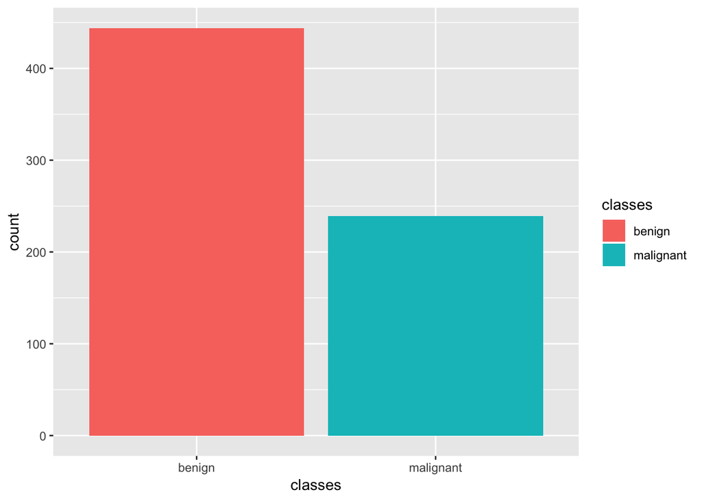

```r
ggplot(bc_data, aes(x = classes, fill = classes)) +
  geom_bar()
```

## Response variable for regression

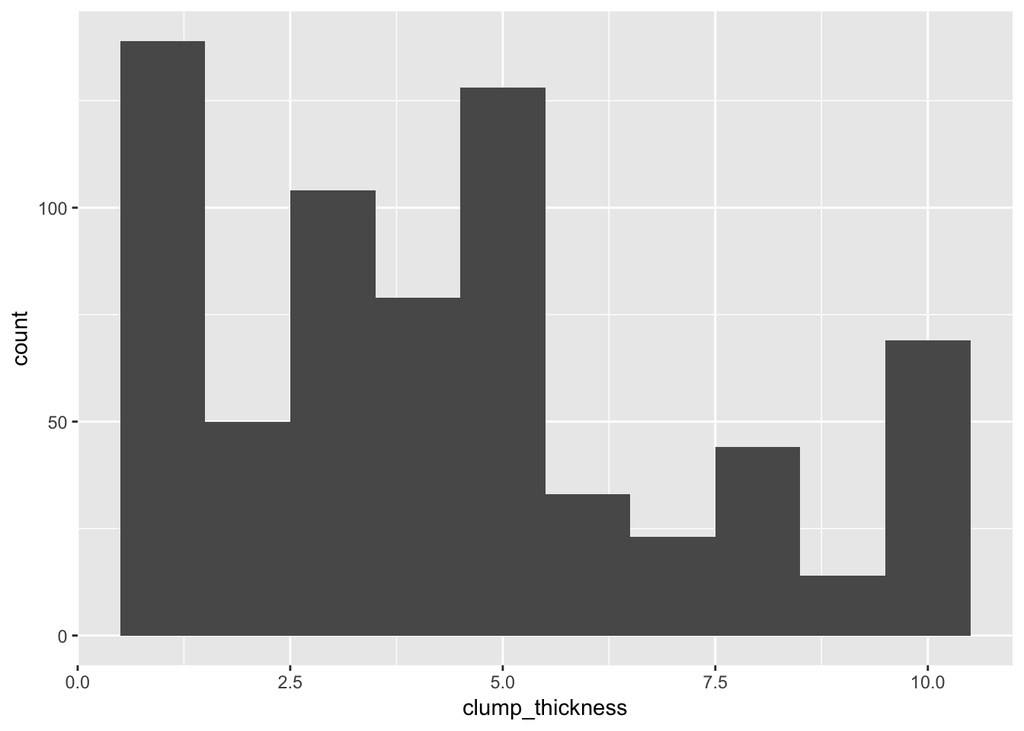

```r
ggplot(bc_data, aes(x = clump_thickness)) +
  geom_histogram(bins = 10)
```

## Features

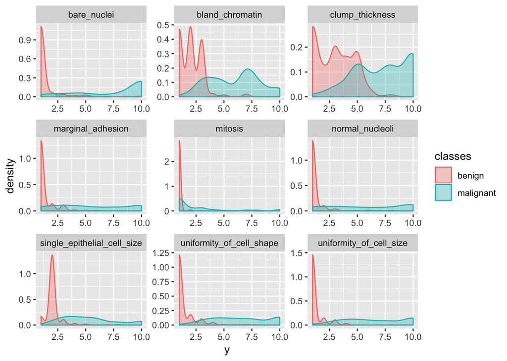

```r
gather(bc_data, x, y, clump_thickness:mitosis) %>%
  ggplot(aes(x = y, color = classes, fill = classes)) +
    geom_density(alpha = 0.3) +
    facet_wrap( ~ x, scales = "free", ncol = 3)
```

## Univariate Plots

Univariate plots to better understand each attribute. Let???s set that up and call the inputs attributes x and the output attribute (or class) y.

[figure not shown]

```r
x <- bc_data[,2:10]
y <- bc_data[,1]
par(mfrow=c(2,5))
    for(i in 2:5) {
        boxplot(x[,i], main=names(bc_data)[i])
    }
```

This gives us a much clearer idea of the distribution of the input attributes.

## Correlation graphs

Now we can look at the interactions between the variables.

```r
co_mat_benign <- filter(bc_data, classes == "benign") %>%
  select(-1) %>%
  cor()

co_mat_malignant <- filter(bc_data, classes == "malignant") %>%
  select(-1) %>%
  cor()

g_benign <- graph.adjacency(co_mat_benign,
                         weighted = TRUE,
                         diag = FALSE,
                         mode = "upper")

g_malignant <- graph.adjacency(co_mat_malignant,
                         weighted = TRUE,
                         diag = FALSE,
                         mode = "upper")


# http://kateto.net/networks-r-igraph

cut.off_b <- mean(E(g_benign)$weight)
cut.off_m <- mean(E(g_malignant)$weight)

g_benign_2 <- delete_edges(g_benign, E(g_benign)[weight < cut.off_b])
g_malignant_2 <- delete_edges(g_malignant, E(g_malignant)[weight < cut.off_m])

c_g_benign_2 <- cluster_fast_greedy(g_benign_2)
c_g_malignant_2 <- cluster_fast_greedy(g_malignant_2)
```

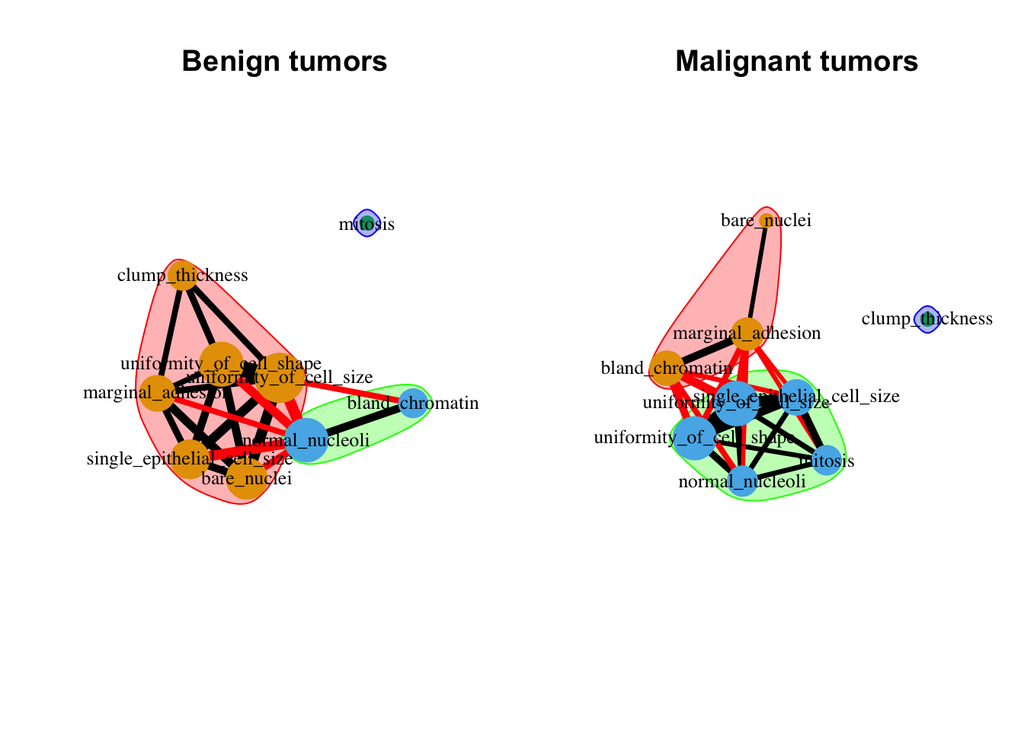

```r
par(mfrow = c(1,2))

plot(c_g_benign_2, g_benign_2,
     vertex.size = colSums(co_mat_benign) * 10,
     vertex.frame.color = NA,
     vertex.label.color = "black",
     vertex.label.cex = 0.8,
     edge.width = E(g_benign_2)$weight * 15,
     layout = layout_with_fr(g_benign_2),
     main = "Benign tumors")

plot(c_g_malignant_2, g_malignant_2,
     vertex.size = colSums(co_mat_malignant) * 10,
     vertex.frame.color = NA,
     vertex.label.color = "black",
     vertex.label.cex = 0.8,
     edge.width = E(g_malignant_2)$weight * 15,
     layout = layout_with_fr(g_malignant_2),
     main = "Malignant tumors")
```

# 4. Principal Component Analysis

- One of the common problems in analysis of complex data comes from a large number of variables, which requires a large amount of memory and computation power.
- This is where Principal Component Analysis (PCA) comes in. It is a technique to reduce the dimension of the feature space by feature extraction.
- For example, if we have 10 variables, in feature extraction, we create new independent variables by combining the old ten variables. By creating new variables it might seem as if more dimensions are introduced, but we select only a few variables from the newly created variables in the order of importance. Then the number of those selected variables is less than what we started with and that???s how we reduce the dimensionality.
- Standardization
- Covariance/Correlation
- Transformation
- Selection Step

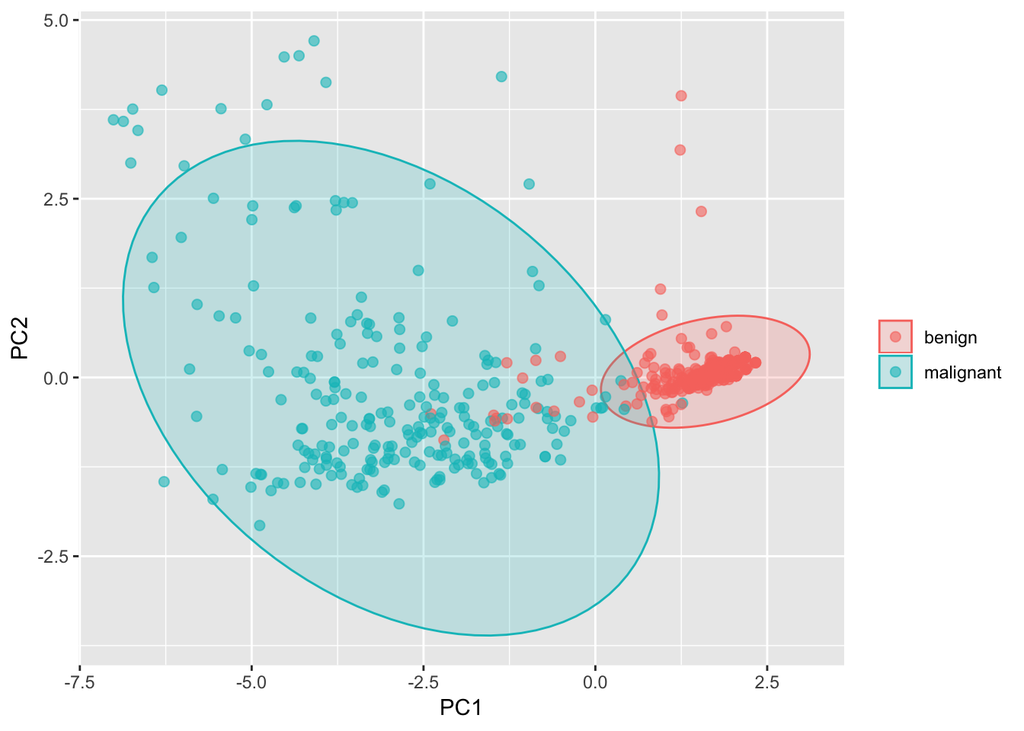

```r
# perform pca and extract scores
pcaOutput <- prcomp(as.matrix(bc_data[, -1]), scale = TRUE, center = TRUE)
pcaOutput2 <- as.data.frame(pcaOutput$x)

# define groups for plotting
pcaOutput2$groups <- bc_data$classes

centroids <- aggregate(cbind(PC1, PC2) ~ groups, pcaOutput2, mean)

conf.rgn  <- do.call(rbind, lapply(unique(pcaOutput2$groups), function(t)
  data.frame(groups = as.character(t),
             ellipse(cov(pcaOutput2[pcaOutput2$groups == t, 1:2]),
                   centre = as.matrix(centroids[centroids$groups == t, 2:3]),
                   level = 0.95),
             stringsAsFactors = FALSE)))

ggplot(data = pcaOutput2, aes(x = PC1, y = PC2, group = groups, color = groups)) +
    geom_polygon(data = conf.rgn, aes(fill = groups), alpha = 0.2) +
    geom_point(size = 2, alpha = 0.6) +
    labs(color = "",
         fill = "")
```

# 5. Multidimensional Scaling

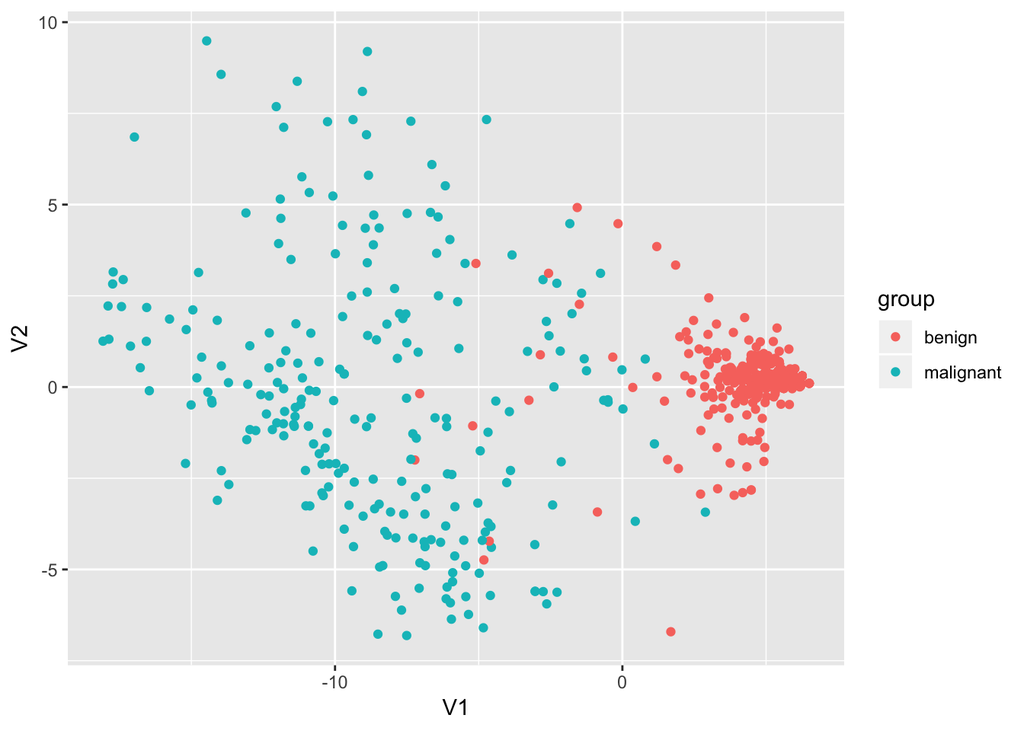

```r
select(bc_data, -1) %>%
  dist() %>%
  cmdscale %>%
  as.data.frame() %>%
  mutate(group = bc_data$classes) %>%
  ggplot(aes(x = V1, y = V2, color = group)) +
    geom_point()
```

# 6. Training, validation and test data

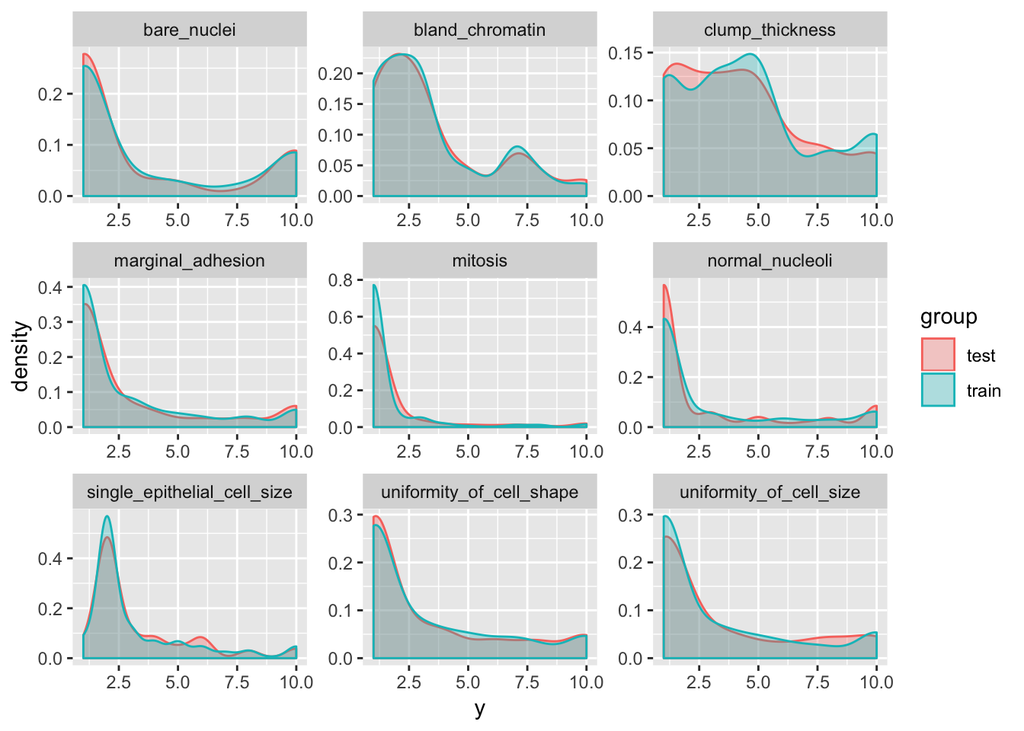

```r
set.seed(42)
index <- createDataPartition(bc_data$classes, p = 0.7, list = FALSE)
train_data <- bc_data[index, ]
test_data  <- bc_data[-index, ]
bind_rows(data.frame(group = "train", train_data),
      data.frame(group = "test", test_data)) %>%
  gather(x, y, clump_thickness:mitosis) %>%
  ggplot(aes(x = y, color = group, fill = group)) +
    geom_density(alpha = 0.3) +
    facet_wrap( ~ x, scales = "free", ncol = 3)
```

# 7. Regression

```r
# configure multicore
library(doParallel)
cl <- makeCluster(detectCores())
registerDoParallel(cl)
```

```r
set.seed(42)
model_glm <- caret::train(clump_thickness ~ .,
                          data = train_data,
                          method = "glm",
                          preProcess = c("scale", "center"),
                          trControl = trainControl(method = "repeatedcv",
                                                  number = 10,
                                                  repeats = 10,
                                                  savePredictions = TRUE,
                                                  verboseIter = FALSE))
model_glm
```

```
## Generalized Linear Model
##
## 479 samples
##   9 predictor
##
## Pre-processing: scaled (9), centered (9)
## Resampling: Cross-Validated (10 fold, repeated 10 times)
## Summary of sample sizes: 432, 431, 432, 432, 431, 431, ...
## Resampling results:
##
##   RMSE      Rsquared   MAE
##   1.961227  0.5312862  1.64155
```

```r
predictions <- predict(model_glm, test_data)
```

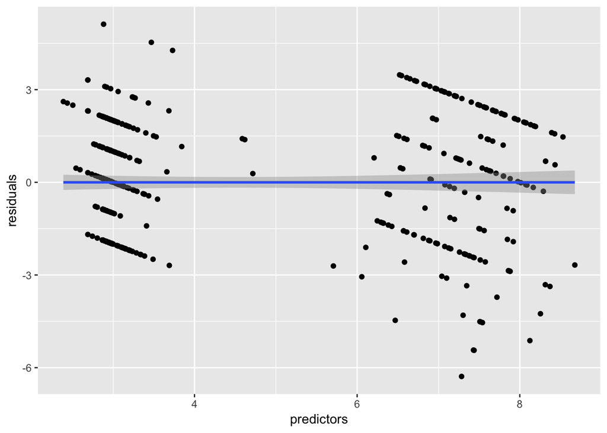

```r
# model_glm$finalModel$linear.predictors == model_glm$finalModel$fitted.values
data.frame(residuals = resid(model_glm),
           predictors = model_glm$finalModel$linear.predictors) %>%
  ggplot(aes(x = predictors, y = residuals)) +
    geom_jitter() +
    geom_smooth(method = "lm")
```

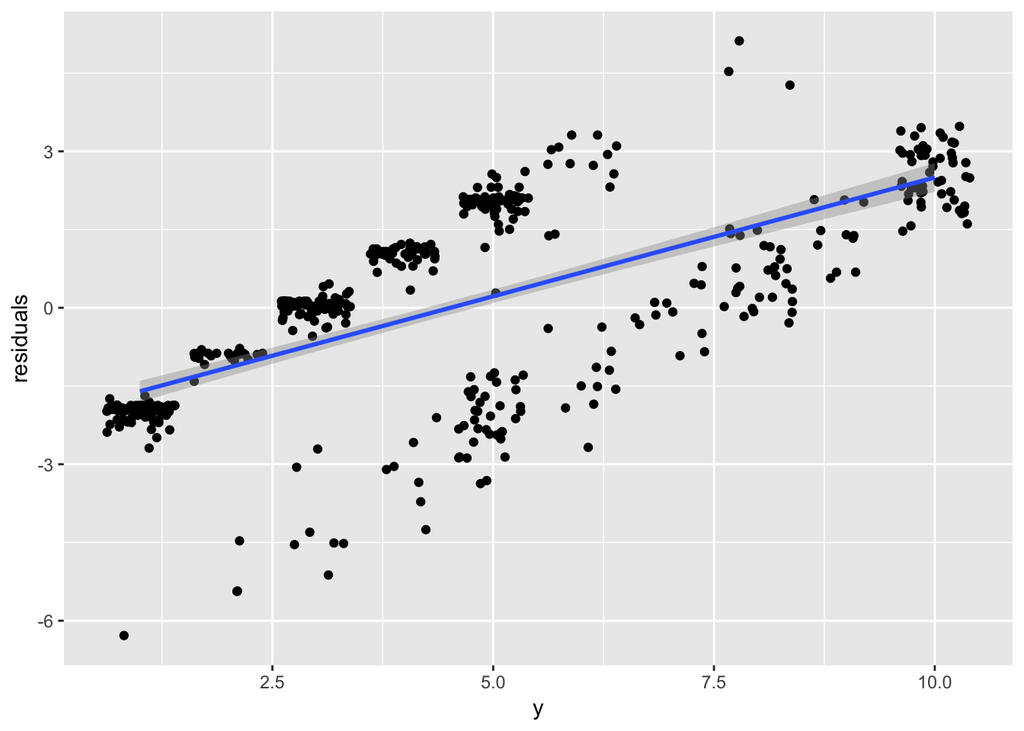

```r
# y == train_data$clump_thickness
data.frame(residuals = resid(model_glm),
           y = model_glm$finalModel$y) %>%
  ggplot(aes(x = y, y = residuals)) +
    geom_jitter() +
    geom_smooth(method = "lm")
```

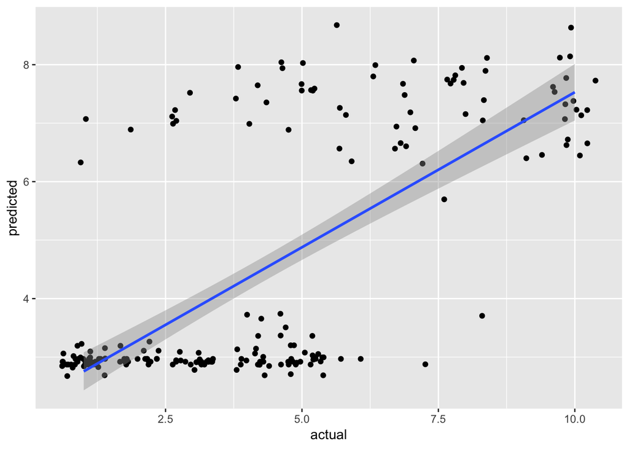

```r
data.frame(actual = test_data$clump_thickness,
           predicted = predictions) %>%
  ggplot(aes(x = actual, y = predicted)) +
    geom_jitter() +
    geom_smooth(method = "lm")
```

# 8. Classification

## 8.1. Decision trees

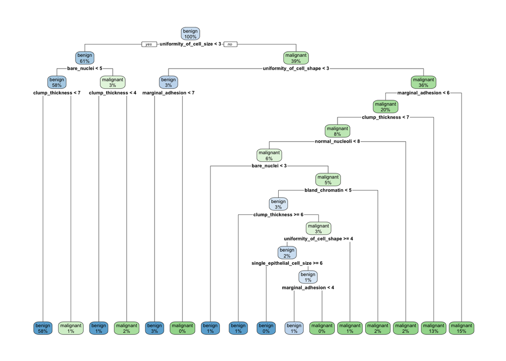

```r
set.seed(42)
fit <- rpart(classes ~ .,
            data = train_data,
            method = "class",
            control = rpart.control(xval = 10,
                                    minbucket = 2,
                                    cp = 0),
             parms = list(split = "information"))

rpart.plot(fit, extra = 100)
```

## 8.2.Random Forests

Random Forests predictions are based on the generation of multiple classification trees. They can be used for both, classification and regression tasks. Here, we see a classification task.

```r
set.seed(42)
model_rf <- caret::train(classes ~ .,
                         data = train_data,
                         method = "rf",
                         preProcess = c("scale", "center"),
                         trControl = trainControl(method = "repeatedcv",
                                                  number = 5,
                                                  repeats = 3,
                                                  savePredictions = TRUE,
                                                  verboseIter = FALSE))
model_rf
```

```
## Random Forest
##
## 479 samples
##   9 predictor
##   2 classes: 'benign', 'malignant'
##
## Pre-processing: scaled (9), centered (9)
## Resampling: Cross-Validated (5 fold, repeated 3 times)
## Summary of sample sizes: 383, 384, 383, 384, 382, 383, ...
## Resampling results across tuning parameters:
##
##   mtry  Accuracy   Kappa
##   2     0.9679528  0.9302554
##   5     0.9575064  0.9070483
##   9     0.9554083  0.9023126
##
## Accuracy was used to select the optimal model using the largest value.
## The final value used for the model was mtry = 2.
```

When you specify savePredictions = TRUE, you can access the cross-validation resuls with `model_rf$pred`.

```r
model_rf$finalModel$confusion
```

```
##           benign malignant class.error
## benign       302         9  0.02893891
## malignant      5       163  0.02976190
```

### 8.3.1 Feature Importance

```r
imp <- model_rf$finalModel$importance
imp[order(imp, decreasing = TRUE), ]
```

```
##     uniformity_of_cell_size    uniformity_of_cell_shape
##                   48.660549                   42.277575
##                 bare_nuclei             normal_nucleoli
##                   39.314258                   26.058721
##             bland_chromatin             clump_thickness
##                   18.420161                   15.067622
## single_epithelial_cell_size           marginal_adhesion
##                   15.064897                    9.751286
##                     mitosis
##                    1.912489
```

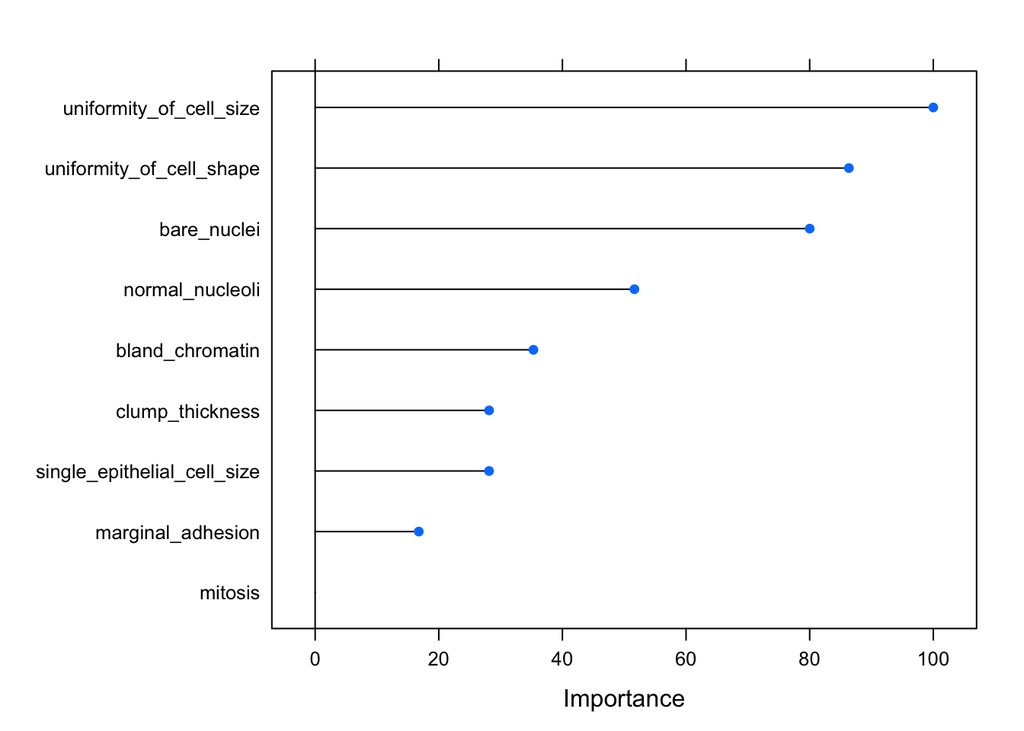

```r
# estimate variable importance
importance <- varImp(model_rf, scale = TRUE)
plot(importance)
```

### 8.3.2 Predicting test data

```r
confusionMatrix(predict(model_rf, test_data), as.factor(test_data$classes))
```

```
## Confusion Matrix and Statistics
##
##            Reference
## Prediction  benign malignant
##   benign       131         1
##   malignant      2        70
##
##                Accuracy : 0.9853
##                  95% CI : (0.9576, 0.997)
##     No Information Rate : 0.652
##     P-Value [Acc > NIR] : <2e-16
##
##                   Kappa : 0.9677
##
##  Mcnemar's Test P-Value : 1
##
##             Sensitivity : 0.9850
##             Specificity : 0.9859
##          Pos Pred Value : 0.9924
##          Neg Pred Value : 0.9722
##              Prevalence : 0.6520
##          Detection Rate : 0.6422
##    Detection Prevalence : 0.6471
##       Balanced Accuracy : 0.9854
##
##        'Positive' Class : benign
##
```

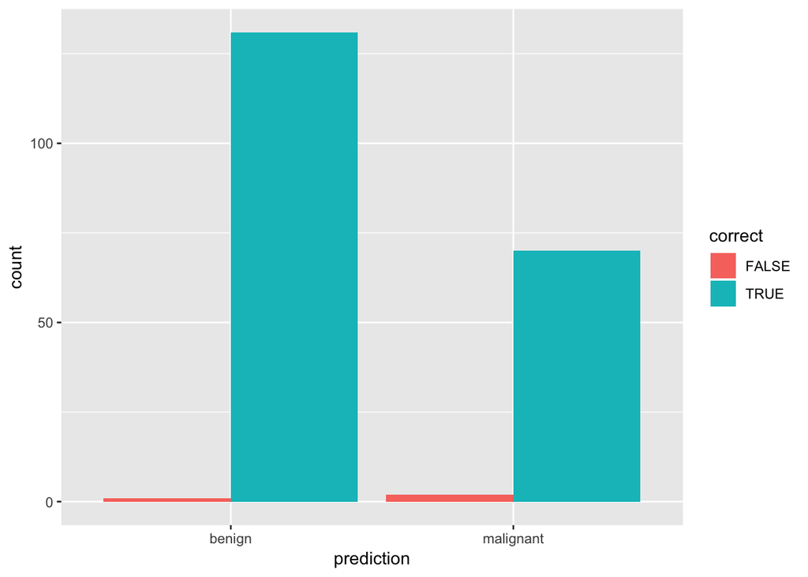

```r
results <- data.frame(actual = test_data$classes,
                      predict(model_rf, test_data, type = "prob"))

results$prediction <- ifelse(results$benign > 0.5, "benign",
                             ifelse(results$malignant > 0.5, "malignant", NA))

results$correct <- ifelse(results$actual == results$prediction, TRUE, FALSE)

ggplot(results, aes(x = prediction, fill = correct)) +
  geom_bar(position = "dodge")
```

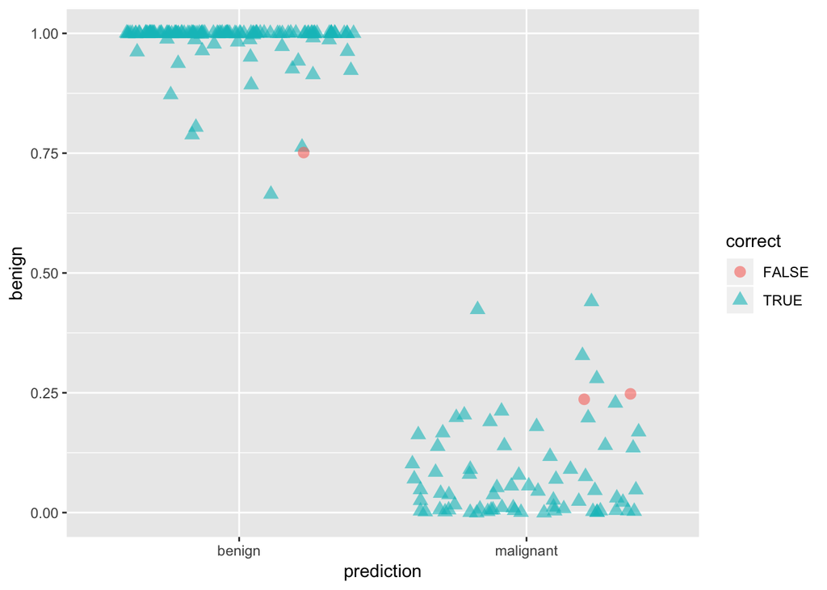

```r
ggplot(results, aes(x = prediction, y = benign, color = correct, shape = correct)) +
  geom_jitter(size = 3, alpha = 0.6)
```

## 8.2 Extreme gradient boosting trees

Extreme gradient boosting (XGBoost) is a faster and improved implementation of gradient boosting for supervised learning.

XGBoost is a tree ensemble model, which means the sum of predictions from a set of classification and regression trees (CART). In that, XGBoost is similar to Random Forests but it uses a different approach to model training. Can be used for classification and regression tasks. Here, let’s see a classification task.

```r
set.seed(42)
model_xgb <- caret::train(classes ~ .,
                          data = train_data,
                          method = "xgbTree",
                          preProcess = c("scale", "center"),
                          trControl = trainControl(method = "repeatedcv",
                                                  number = 5,
                                                  repeats = 3,
                                                  savePredictions = TRUE,
                                                  verboseIter = FALSE))
model_xgb
```

```
## eXtreme Gradient Boosting
##
## 479 samples
##   9 predictor
##   2 classes: 'benign', 'malignant'
##
## Pre-processing: scaled (9), centered (9)
## Resampling: Cross-Validated (5 fold, repeated 3 times)
## Summary of sample sizes: 383, 384, 383, 384, 382, 383, ...
## Resampling results across tuning parameters:
##
##   eta  max_depth  colsample_bytree  subsample  nrounds  Accuracy
##   0.3  1          0.6               0.50        50      0.9575067
##   0.3  1          0.6               0.50       100      0.9554375
##   0.3  1          0.6               0.50       150      0.9568411
##   0.3  1          0.6               0.75        50      0.9575137
##   0.3  1          0.6               0.75       100      0.9582155
##   0.3  1          0.6               0.75       150      0.9602842
##   0.3  1          0.6               1.00        50      0.9588954
##   0.3  1          0.6               1.00       100      0.9547140
##   0.3  1          0.6               1.00       150      0.9568047
##   0.3  1          0.8               0.50        50      0.9595899
##   0.3  1          0.8               0.50       100      0.9561172
##   0.3  1          0.8               0.50       150      0.9560954
##   0.3  1          0.8               0.75        50      0.9561248
##   0.3  1          0.8               0.75       100      0.9561247
##   0.3  1          0.8               0.75       150      0.9595972
##   0.3  1          0.8               1.00        50      0.9540123
##   0.3  1          0.8               1.00       100      0.9540123
##   0.3  1          0.8               1.00       150      0.9554158
##   0.3  2          0.6               0.50        50      0.9609789
##   0.3  2          0.6               0.50       100      0.9603352
##   0.3  2          0.6               0.50       150      0.9617022
##   0.3  2          0.6               0.75        50      0.9595972
##   0.3  2          0.6               0.75       100      0.9630769
##   0.3  2          0.6               0.75       150      0.9637858
##   0.3  2          0.6               1.00        50      0.9609788
##   0.3  2          0.6               1.00       100      0.9602843
##   0.3  2          0.6               1.00       150      0.9595899
##   0.3  2          0.8               0.50        50      0.9623530
```

[output cut: 182 more lines]

```
##   0.9245350
##   0.9256377
##   0.9366260
##   0.9273771
##   0.9119037
##   0.9210319
##   0.9256867
##
## Tuning parameter 'gamma' was held constant at a value of 0
##
## Tuning parameter 'min_child_weight' was held constant at a value of 1
## Accuracy was used to select the optimal model using the largest value.
## The final values used for the model were nrounds = 100, max_depth = 3,
##  eta = 0.4, gamma = 0, colsample_bytree = 0.8, min_child_weight = 1
##  and subsample = 0.75.
```

### 8.2.1 Feature Importance

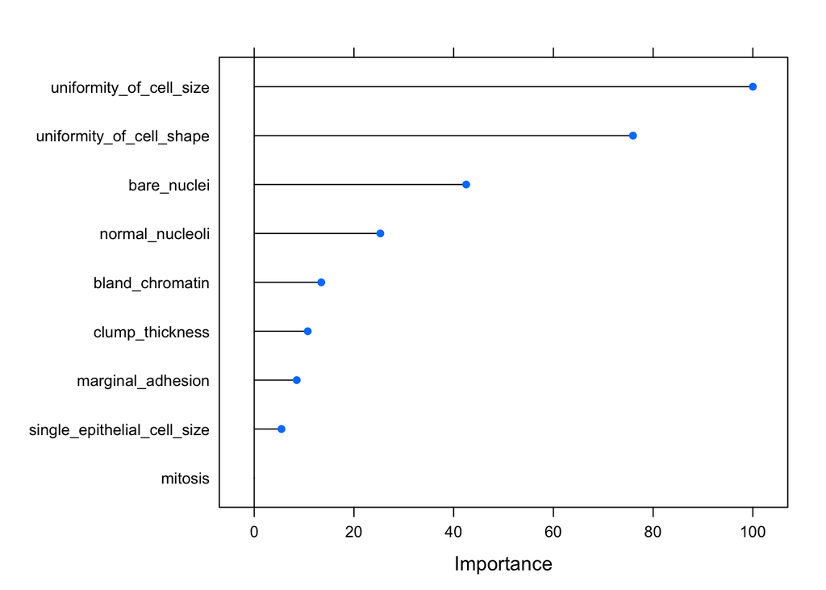

```r
importance <- varImp(model_xgb, scale = TRUE)
plot(importance)
```

### 8.2.2 Predicting test data

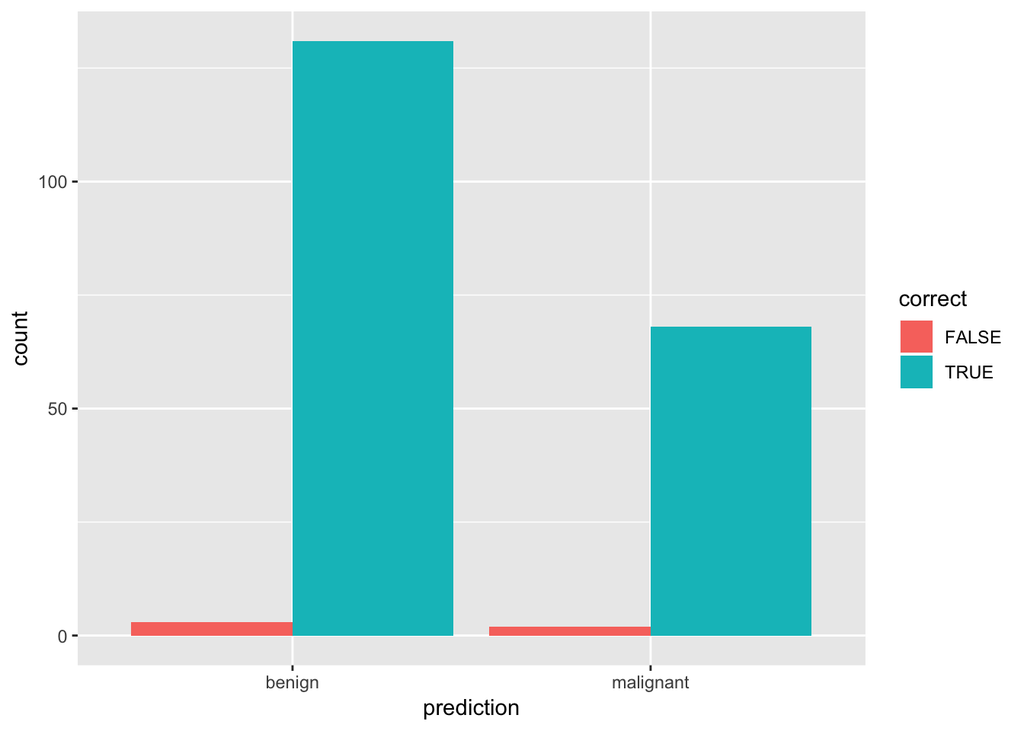

```r
results <- data.frame(actual = test_data$classes,
                      predict(model_xgb, test_data, type = "prob"))

results$prediction <- ifelse(results$benign > 0.5, "benign",
                             ifelse(results$malignant > 0.5, "malignant", NA))

results$correct <- ifelse(results$actual == results$prediction, TRUE, FALSE)

ggplot(results, aes(x = prediction, fill = correct)) +
  geom_bar(position = "dodge")
```

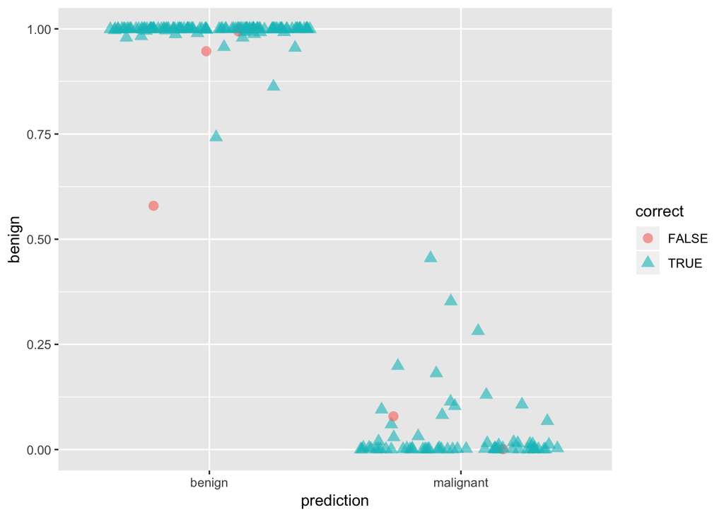

```r
ggplot(results, aes(x = prediction, y = benign, color = correct, shape = correct)) +
  geom_jitter(size = 3, alpha = 0.6)
```